# glinski_metabolites

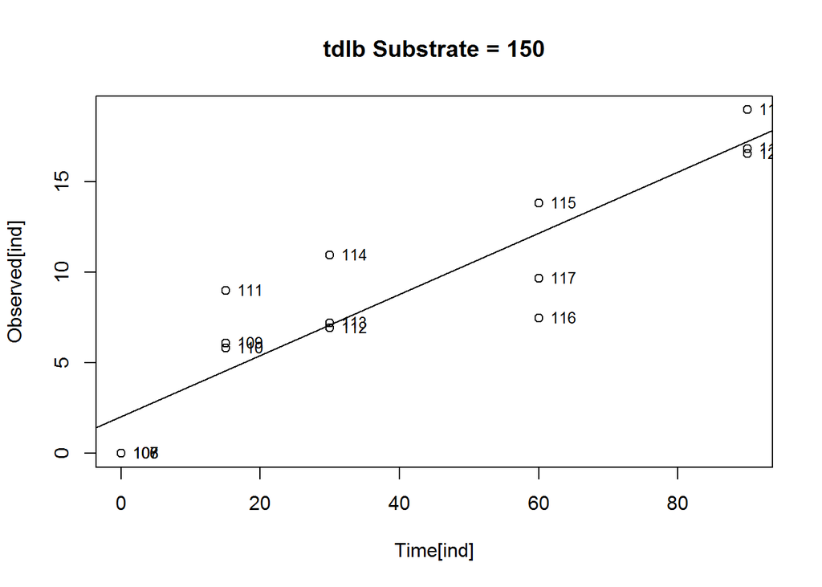

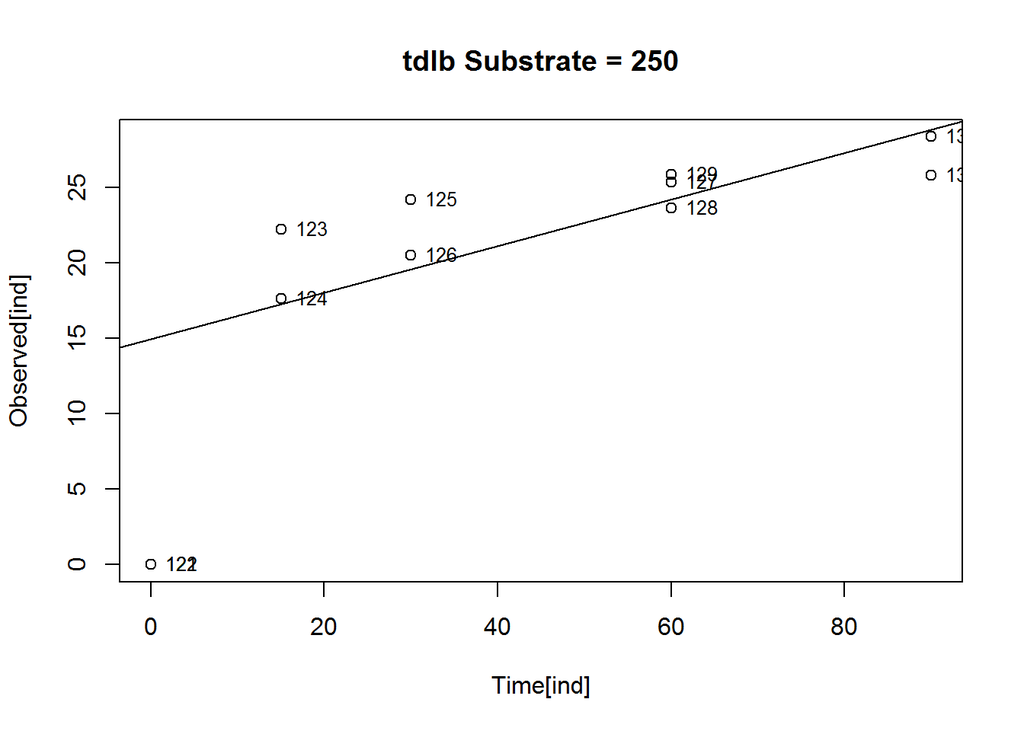

```
## [1] "here are the rates"
```

```
##
## Model fitted: Michaelis-Menten (2 parms)
##
## Parameter estimates:
##
##                Estimate Std. Error   t-value p-value
## d:(Intercept) 1299.5681   282.4222    4.6015  0.0025
## e:(Intercept)  130.7062    57.0056    2.2929  0.0556
##
## Residual standard error:
##
##  83.93925 (7 degrees of freedom)
```

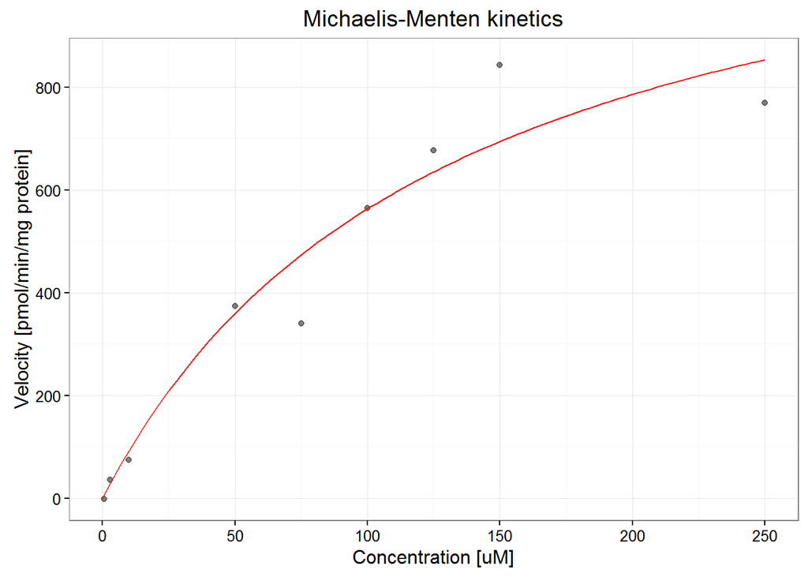

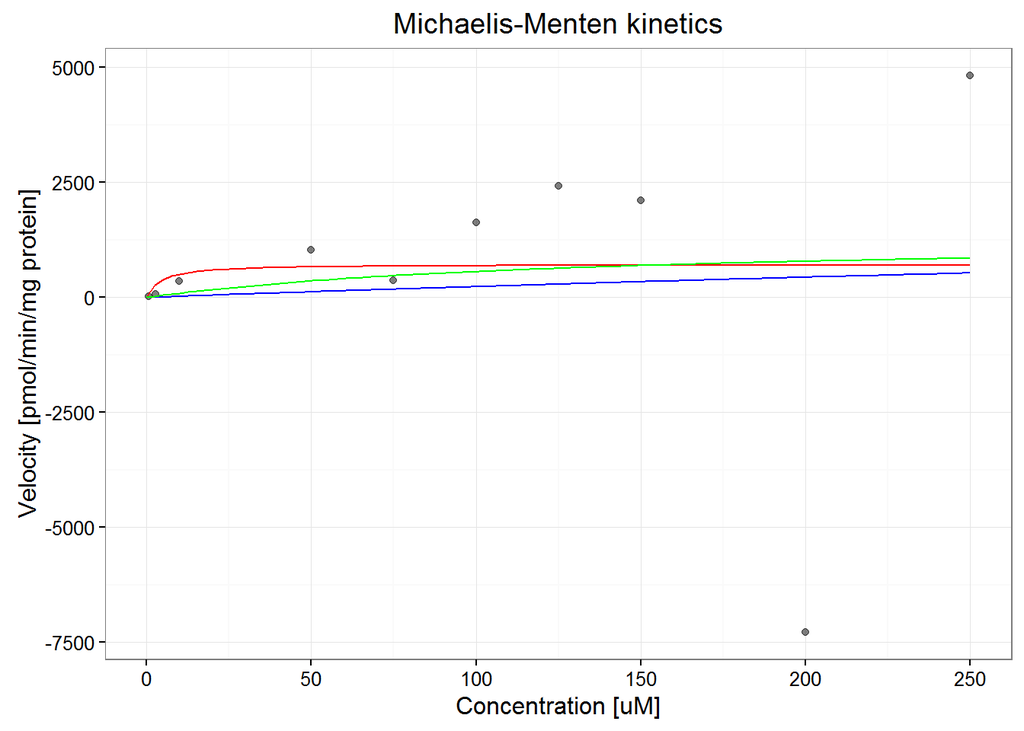

# fipronil

```
## [1] "Substrates:"
```

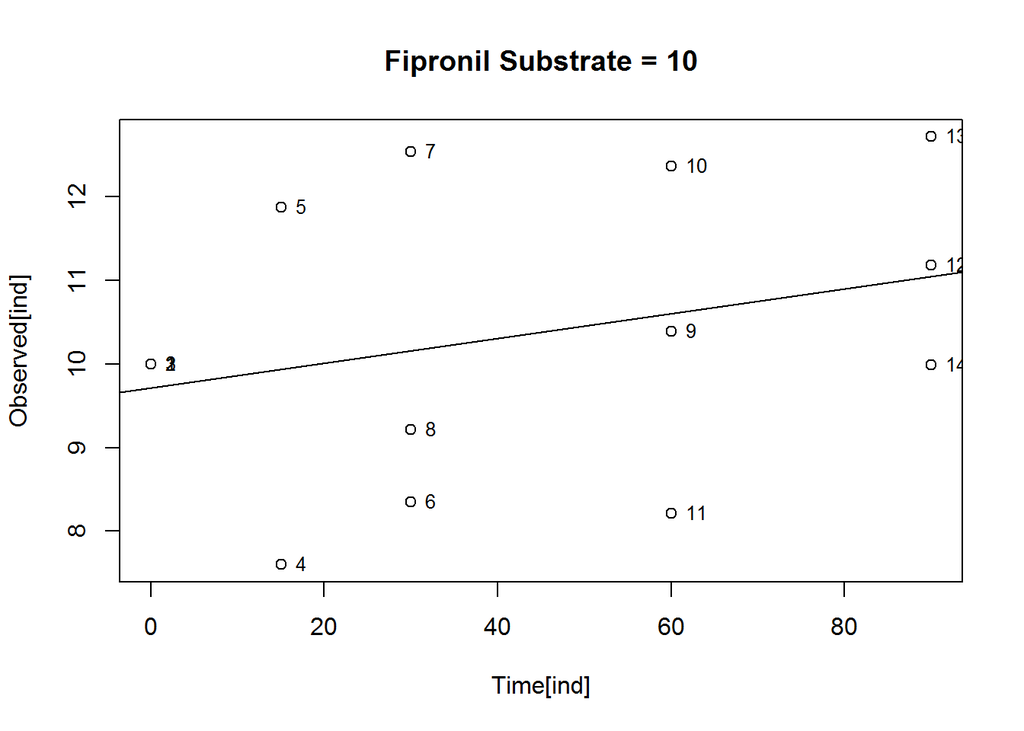

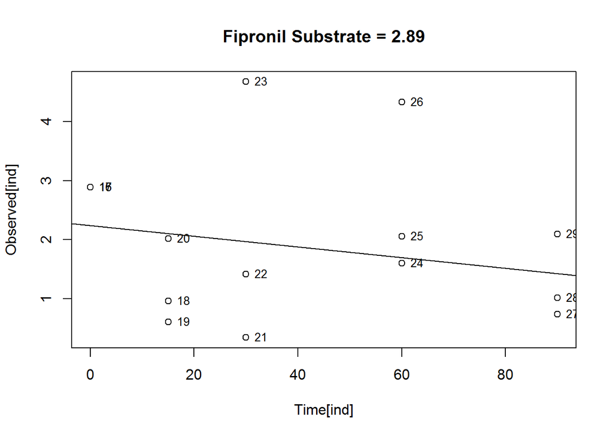

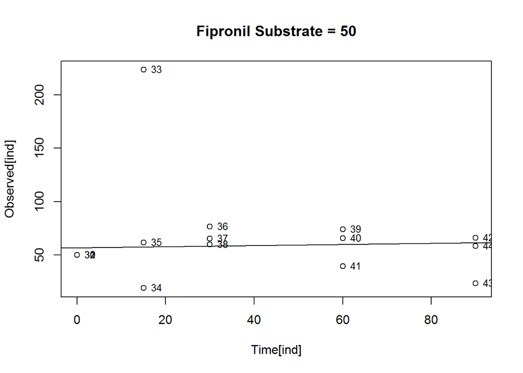

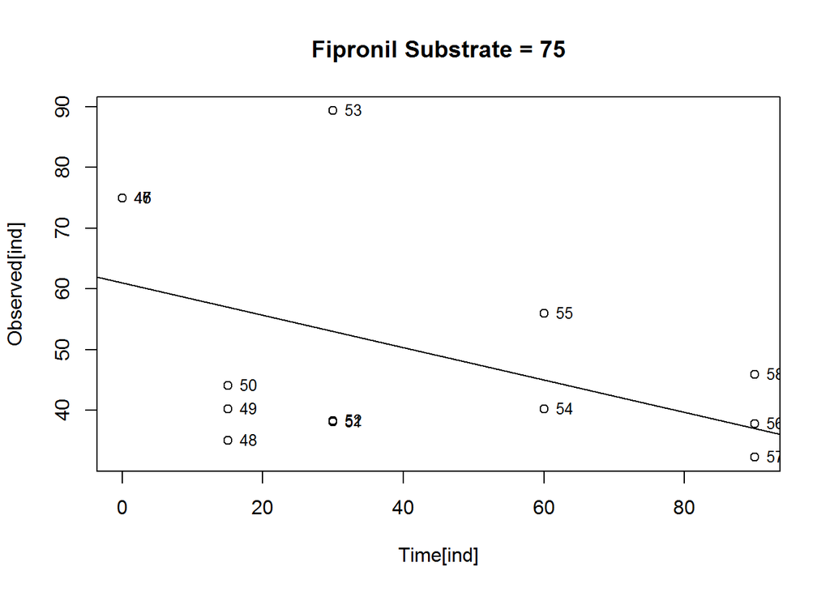

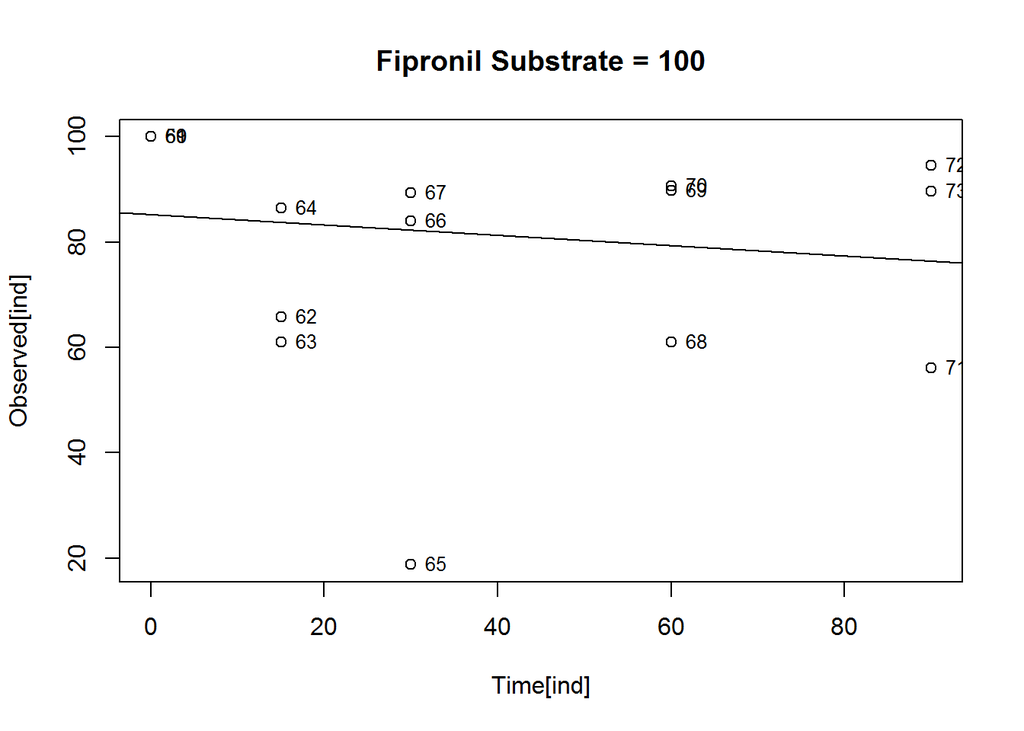

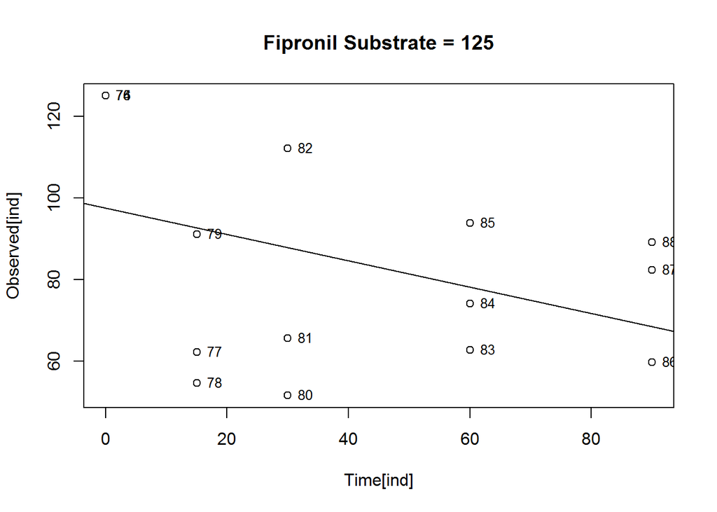

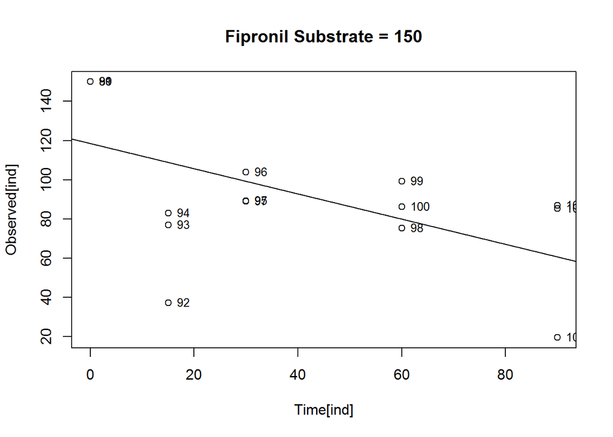

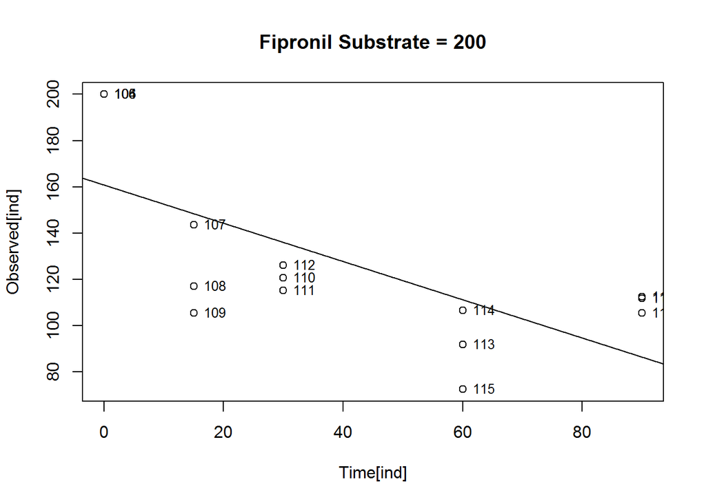

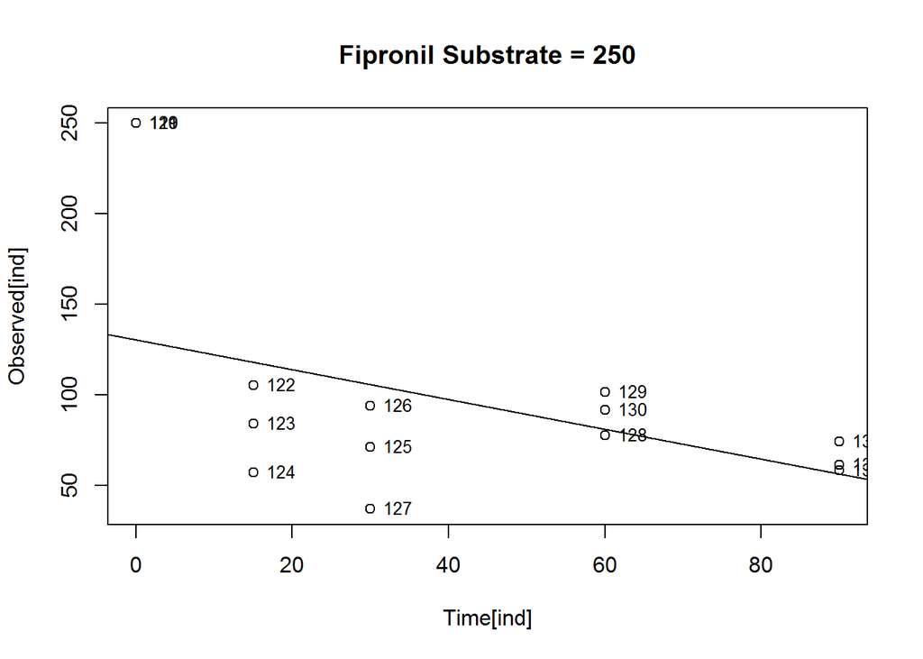

```
## [1] "here are the rates"
```

```
##
## Model fitted: Michaelis-Menten (2 parms)
##
## Parameter estimates:
##
##                 Estimate Std. Error    t-value p-value
## d:(Intercept) 1.3471e+05 3.4533e+05 3.9011e-01  0.7081
## e:(Intercept) 7.8115e+03 2.0475e+04 3.8152e-01  0.7141
##
## Residual standard error:
##
##  764.2409 (7 degrees of freedom)
```

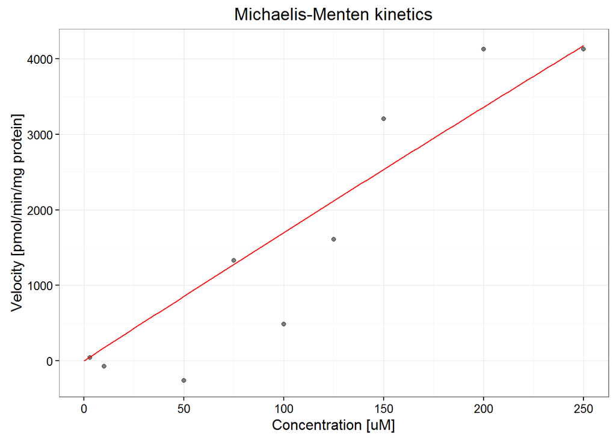

# fipsulf

```
## [1] "Substrates:"
```

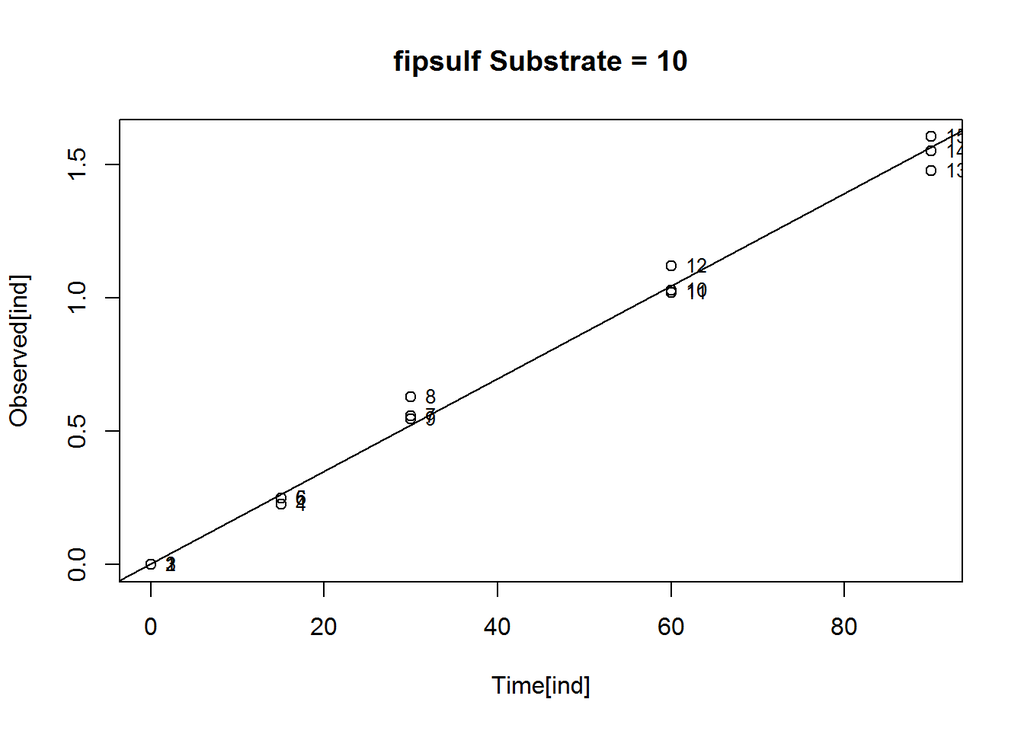

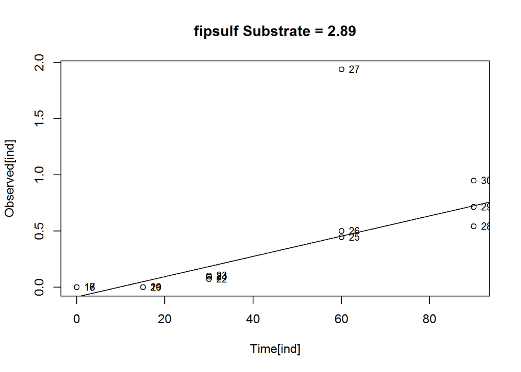

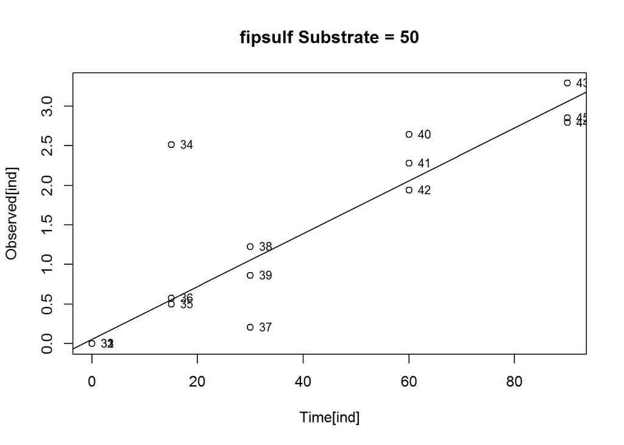

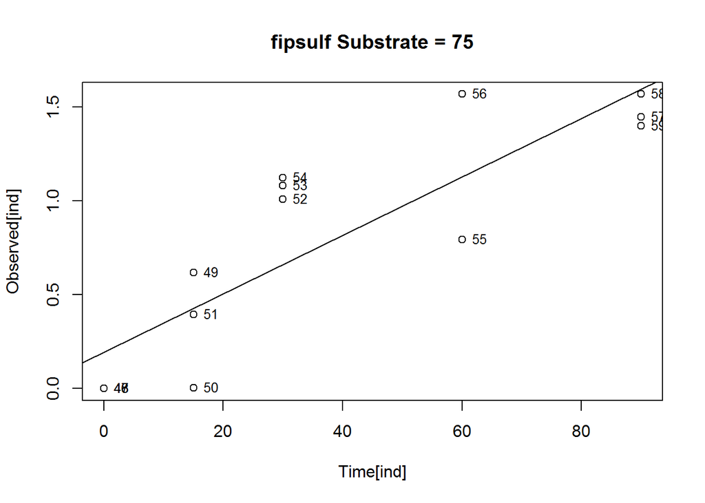

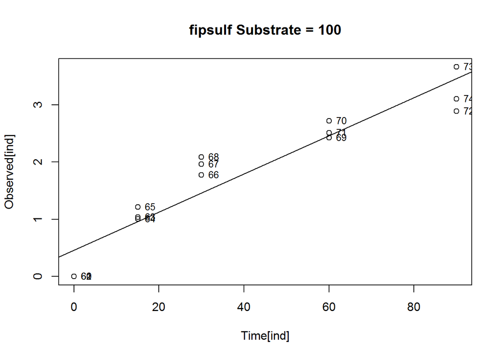

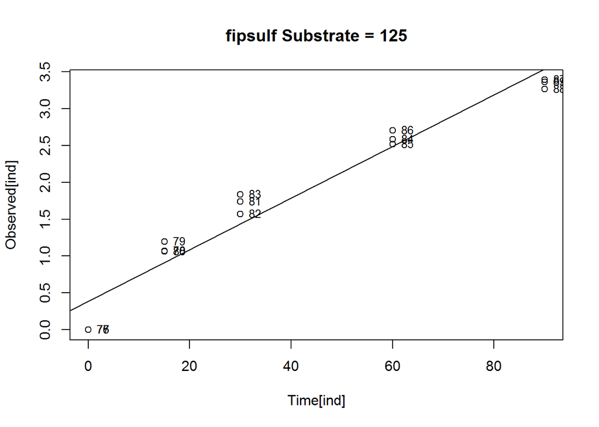

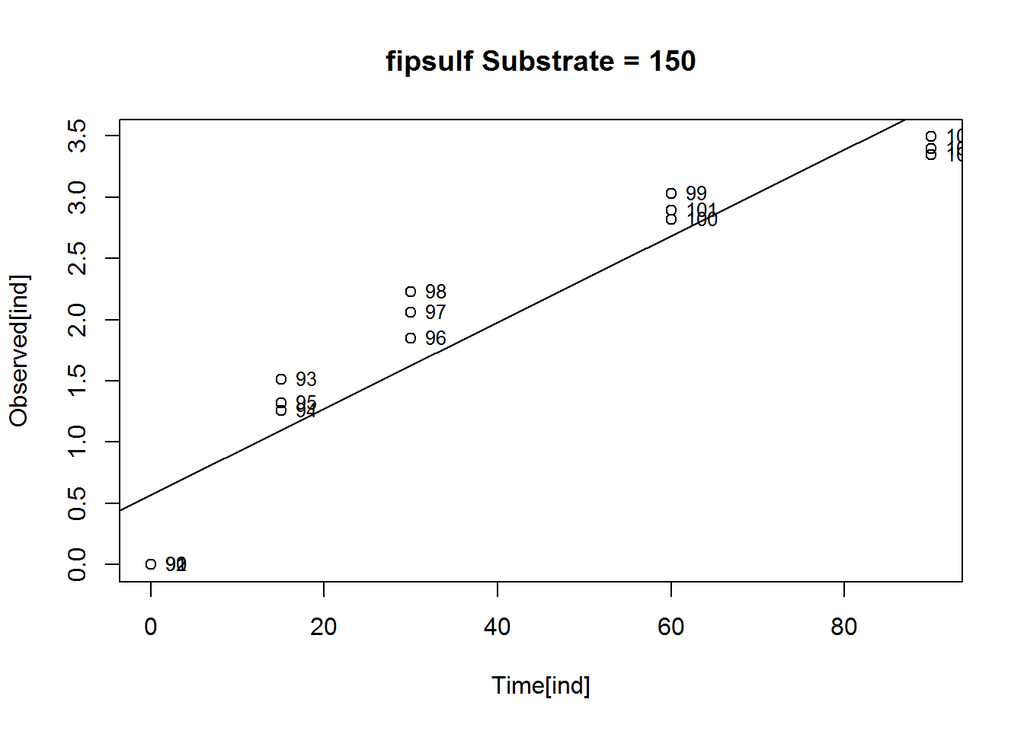

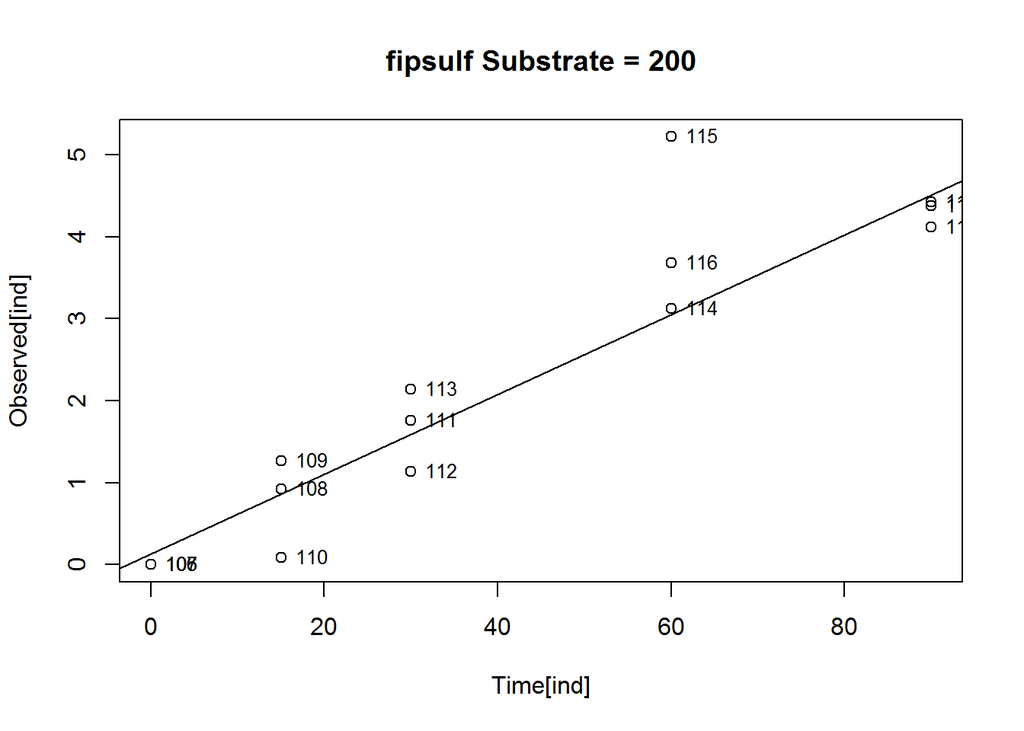

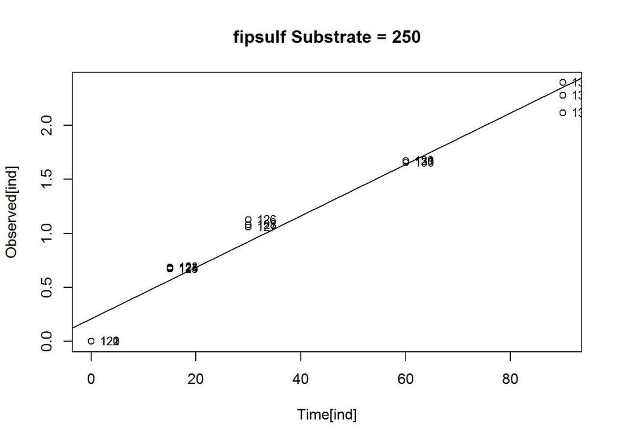

```
## [1] "here are the rates"
```

```
##
## Model fitted: Michaelis-Menten (2 parms)
##
## Parameter estimates:
##
##                Estimate Std. Error   t-value p-value
## d:(Intercept) 177.90201   27.92410   6.37091  0.0004
## e:(Intercept)  10.95581   11.57501   0.94651  0.3754
##
## Residual standard error:
##
##  46.2558 (7 degrees of freedom)
```

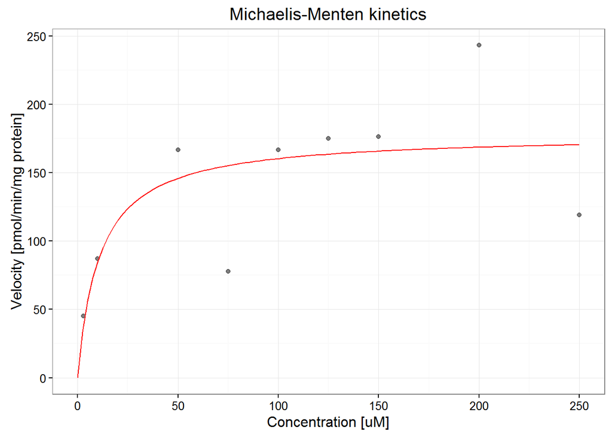

# exposure experiment analysis

Results presentation and discussion for parent analytes (atrazine, triadimenon, and fipronil) and their xenobiotic metabolites.

Toxicity of parents and metabolites discussion.

Microsomal analysis of soil and amphibian data for 0 (soil only), 2, 4, 12, 24, and 48 hours after exposure.

Database has factors for time, parent (mapped to analyte), analyte (can be either parent or metabolite), matrix (amphibian or soil), and tank (potentially a nuisance variable).

[output not shown]

[output cut: 58 more lines]

[output not shown]

```
## Source: local data frame [352 x 6]
## Groups: parent, analyte, matrix, time [86]
##
##     time   parent  analyte matrix     conc replicate
##    (int)   (fctr)   (fctr) (fctr)    (dbl)    (fctr)
## 1      2 atrazine atrazine amphib 3.068203         1
## 2      2 atrazine atrazine amphib 3.689640         2
## 3      2 atrazine atrazine amphib 4.701166         3
## 4      2 atrazine atrazine amphib 1.892494         4
## 5      4 atrazine atrazine amphib 7.624610         1
## 6      4 atrazine atrazine amphib 4.134300         2
## 7      4 atrazine atrazine amphib 2.050779         3
## 8      4 atrazine atrazine amphib 7.626486         4
## 9     12 atrazine atrazine amphib 2.452278         1
## 10    12 atrazine atrazine amphib 3.786893         2
## ..   ...      ...      ...    ...      ...       ...
```

```
## Source: local data frame [86 x 7]
## Groups: parent, analyte, matrix [?]
##
##      parent  analyte matrix  time count  ConcMean    ConcSD
##      (fctr)   (fctr) (fctr) (int) (int)     (dbl)     (dbl)
## 1  atrazine atrazine amphib     2     4  3.337876 1.1753225
## 2  atrazine atrazine amphib     4     4  5.359044 2.7518903
## 3  atrazine atrazine amphib    12     4  3.123811 1.2566289
## 4  atrazine atrazine amphib    24     4  1.554919 0.6096102
## 5  atrazine atrazine amphib    48     4  1.001887 0.3545473
## 6  atrazine atrazine   soil     0     4 15.930920 2.5911041
## 7  atrazine atrazine   soil     2     4 19.029034 4.3534303
## 8  atrazine atrazine   soil     4     4 18.770091 2.6953158
## 9  atrazine atrazine   soil    12     4 20.614190 3.8918511
## 10 atrazine atrazine   soil    24     4 24.996196 4.4473828
## ..      ...      ...    ...   ...   ...       ...       ...
```

[output not shown]

[output cut: 65 more lines]

The amphibian data set summary statistics. Atrazine peaks at 4 hours and then declines monotonically. DEA peaks at 12 hours and DIA at 24. Fipronil steadily declines from its first observation at 2 hours with fipronil sulfone not peaking until 24 hours. Triadimenon peaks at 24 hours with its metabolites tdla and tdlb peaking at 4 hours.

```
## Classes 'grouped_df', 'tbl_df', 'tbl' and 'data.frame':  86 obs. of  7 variables:
##  $ parent  : Factor w/ 3 levels "atrazine","fipronil",..: 1 1 1 1 1 1 1 1 1 1 ...
##  $ analyte : Factor w/ 8 levels "atrazine","dea",..: 1 1 1 1 1 1 1 1 1 1 ...
##  $ matrix  : Factor w/ 2 levels "amphib","soil": 1 1 1 1 1 2 2 2 2 2 ...
##  $ time    : int  2 4 12 24 48 0 2 4 12 24 ...
##  $ count   : int  4 4 4 4 4 4 4 4 4 4 ...
##  $ ConcMean: num  3.34 5.36 3.12 1.55 1 ...
##  $ ConcSD  : num  1.175 2.752 1.257 0.61 0.355 ...
##  - attr(*, "vars")=List of 3
##   ..$ : symbol parent
##   ..$ : symbol analyte
##   ..$ : symbol matrix
##  - attr(*, "drop")= logi TRUE
```

```
## Source: local data frame [6 x 7]
## Groups: parent, analyte, matrix [2]
##
##     parent  analyte matrix  time count   ConcMean     ConcSD
##     (fctr)   (fctr) (fctr) (int) (int)      (dbl)      (dbl)
## 1 atrazine atrazine amphib     2     4 3.33787563 1.17532253
## 2 atrazine atrazine amphib     4     4 5.35904387 2.75189034
## 3 atrazine atrazine amphib    12     4 3.12381130 1.25662887
## 4 atrazine atrazine amphib    24     4 1.55491895 0.60961016
## 5 atrazine atrazine amphib    48     4 1.00188749 0.35454734
## 6 atrazine      dea amphib     2     4 0.01389877 0.00522407
```